# Playing around with BRFSS data using MR and NN

## 1 - Environment

```python
import subprocess, sys
import os

os.environ['CUDA_LAUNCH_BLOCKING'] = '1'
pkgs = ['torch','scikit-learn','pandas','numpy','matplotlib',
        'seaborn','shap','scipy','statsmodels','nbformat']
for p in pkgs:
    subprocess.run([sys.executable,'-m','pip','install',p,'-q'])
print('Done.')
```

```
Done.
```

## 2 - Configuration and Imports

```python
# ── USER CONFIG ────────────────────────────────────────────────────────────
CSV_PATH        = "brfss2024_clean_20260402.csv"
SEED            = 42
WEIGHT_TRIM_PCT = 99
RELIABLE_N      = 30
MI_DATASETS     = 5
ALPHA_CONFORMAL = 0.10
HIDDEN_DIMS     = [128, 64, 32]
DROPOUT         = 0.3
LR              = 1e-3
WEIGHT_DECAY    = 1e-4
BATCH_SIZE      = 2048
MAX_EPOCHS      = 100
PATIENCE        = 10
STATE_EMB_DIM   = 4
# ───────────────────────────────────────────────────────────────────────────

import warnings; warnings.filterwarnings('ignore')
import numpy as np
import pandas as pd
import matplotlib.pyplot as plt
import matplotlib.gridspec as gridspec
from scipy.stats import chi2_contingency

import torch
import torch.nn as nn
import torch.nn.functional as F
import torch.optim as optim
from torch.utils.data import DataLoader, TensorDataset

from sklearn.model_selection import train_test_split
from sklearn.preprocessing import OneHotEncoder
from sklearn.linear_model import LogisticRegression as SKLogistic
from sklearn.metrics import roc_auc_score, brier_score_loss
from sklearn.experimental import enable_iterative_imputer  # noqa
from sklearn.impute import IterativeImputer

import statsmodels.api as sm

np.random.seed(SEED)
torch.manual_seed(SEED)

DEVICE = torch.device('cuda' if torch.cuda.is_available() else 'cpu')
print(f'PyTorch device: {DEVICE}')
if DEVICE.type == 'cuda':
    print(f'  GPU: {torch.cuda.get_device_name(0)}')
    print(f'  VRAM: {torch.cuda.get_device_properties(0).total_memory/1e9:.1f} GB')
```

```
PyTorch device: cuda
  GPU: NVIDIA GeForce RTX 2060
  VRAM: 6.4 GB
```

## 3 - Load and Clean

```python
KEEP_COLS = ['_STATE','_BMI5CAT','_BMI5',
             '_SEX','_AGEG5YR','_RACE','_EDUCAG','_INCOMG1',
             '_LLCPWT','_STSTR','_PSU']

df_raw = pd.read_csv(CSV_PATH, usecols=KEEP_COLS, low_memory=False)
print(f'Raw shape: {df_raw.shape}')

MISSING_CODES = {
    '_BMI5':    [9999],
    '_AGEG5YR': [14],
    '_RACE':    [9],
    '_EDUCAG':  [9],
    '_INCOMG1': [9],
}
df = df_raw.copy()
for col, codes in MISSING_CODES.items():
    df[col] = df[col].replace(codes, np.nan)

# Physiological BMI filter
bmi_actual = df['_BMI5'] / 100
implausible = (bmi_actual < 10) | (bmi_actual > 80)
print(f'Implausible BMI removed: {implausible.sum():,}')
df.loc[implausible, ['_BMI5','_BMI5CAT']] = np.nan

# Binary outcome from continuous BMI (avoids CDC rounding at boundary 30.0)
df['obese'] = np.where(df['_BMI5']/100 >= 30.0, 1.0,
              np.where(df['_BMI5'].isna(), np.nan, 0.0))

df = df.dropna(subset=['obese','_LLCPWT']).reset_index(drop=True)

print(f'Clean shape:       {df.shape}')
print(f'Obese prevalence:  {df["obese"].mean()*100:.1f}%')
print(f'Missing _INCOMG1:  {df["_INCOMG1"].isna().sum():,} '
      f'({df["_INCOMG1"].isna().mean()*100:.1f}%)')
print(f'Missing _AGEG5YR:  {df["_AGEG5YR"].isna().sum():,} '
      f'({df["_AGEG5YR"].isna().mean()*100:.1f}%)')

CAT_FEATURES = ['_SEX','_AGEG5YR','_RACE','_EDUCAG','_INCOMG1']
VALID_CODES  = {
    '_SEX':     [1, 2],
    '_AGEG5YR': list(range(1, 14)),
    '_RACE':    list(range(1, 9)),
    '_EDUCAG':  [1, 2, 3, 4],
    '_INCOMG1': list(range(1, 8)),
}
CELL_COLS = CAT_FEATURES
RACE_LABELS = {1:'NH-White',2:'NH-Black',3:'AIAN',4:'Asian',
               5:'NHOPI',6:'Other',7:'Multiracial',8:'Hispanic'}
```

```
Raw shape: (457670, 11)
Implausible BMI removed: 103
Clean shape:       (414530, 12)
Obese prevalence:  33.7%
Missing _INCOMG1:  63,509 (15.3%)
Missing _AGEG5YR:  4,484 (1.1%)
```

## 4 - Missing Data Mechanism Test (MCAR chi-square)

p < 0.05 rejects MCAR for that variable pair. Expected result: income missingness correlated with race and education -> MAR assumed -> multiple imputation.

```python
print('=== Chi-square: is missingness independent of observed variables? ===')
print('p < 0.05 rejects MCAR\n')

for missing_col in ['_INCOMG1', '_AGEG5YR']:
    flag = df[missing_col].isna().astype(int)
    for predictor in ['_SEX','_RACE','_EDUCAG','_STATE']:
        obs = df[predictor].dropna()
        idx = obs.index.intersection(flag.index)
        ct  = pd.crosstab(flag.loc[idx], obs.loc[idx])
        if ct.shape[1] < 2: continue
        chi2, p, _, _ = chi2_contingency(ct)
        sig = '*** MCAR REJECTED' if p < 0.05 else 'OK'
        print(f'  {missing_col} missing X {predictor}: '
              f'chi2={chi2:.1f}  p={p:.4f}  {sig}')
    print()

# Missingness indicators for nn input
df['_INCOMG1_missing'] = df['_INCOMG1'].isna().astype(float)
df['_AGEG5YR_missing'] = df['_AGEG5YR'].isna().astype(float)
print('Missingness indicators added to df')
```

```
=== Chi-square: is missingness independent of observed variables? ===
p < 0.05 rejects MCAR

  _INCOMG1 missing X _SEX: chi2=600.4  p=0.0000  *** MCAR REJECTED
  _INCOMG1 missing X _RACE: chi2=325.1  p=0.0000  *** MCAR REJECTED
  _INCOMG1 missing X _EDUCAG: chi2=2760.3  p=0.0000  *** MCAR REJECTED
  _INCOMG1 missing X _STATE: chi2=1887.0  p=0.0000  *** MCAR REJECTED

  _AGEG5YR missing X _SEX: chi2=47.0  p=0.0000  *** MCAR REJECTED
  _AGEG5YR missing X _RACE: chi2=204.2  p=0.0000  *** MCAR REJECTED
  _AGEG5YR missing X _EDUCAG: chi2=87.2  p=0.0000  *** MCAR REJECTED
  _AGEG5YR missing X _STATE: chi2=374.3  p=0.0000  *** MCAR REJECTED

Missingness indicators added to df
```

## 5 - Survey Weight Trimming and Design Effect

```
Trim threshold (p99): 5,182.5
Records trimmed:  4,146 (1.00%)
ESS before:       80,942
ESS after:        122,961

National DEFF: 0.002  (expected 1.5-2.5 for BRFSS national estimates)
  sqrt(DEFF) = 0.043  (SE inflation factor for reported CIs)
```

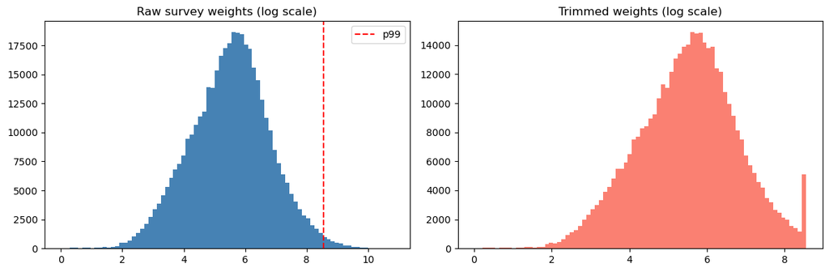

```python
p_trim = np.percentile(df['_LLCPWT'], WEIGHT_TRIM_PCT)
df['_LLCPWT_trimmed'] = np.clip(df['_LLCPWT'], None, p_trim)
df['_LLCPWT_s'] = df['_LLCPWT_trimmed'] / df['_LLCPWT_trimmed'].mean()

ESS_before = df['_LLCPWT'].sum()**2 / (df['_LLCPWT']**2).sum()
ESS_after  = df['_LLCPWT_trimmed'].sum()**2 / (df['_LLCPWT_trimmed']**2).sum()
n_trimmed  = (df['_LLCPWT'] > p_trim).sum()

print(f'Trim threshold (p{WEIGHT_TRIM_PCT}): {p_trim:,.1f}')
print(f'Records trimmed:  {n_trimmed:,} ({n_trimmed/len(df)*100:.2f}%)')
print(f'ESS before:       {ESS_before:,.0f}')
print(f'ESS after:        {ESS_after:,.0f}')

y_arr   = df['obese'].values
w_arr   = df['_LLCPWT_trimmed'].values
p_hat_n = np.average(y_arr, weights=w_arr)
var_wt  = np.average((y_arr - p_hat_n)**2, weights=w_arr) / (w_arr.sum() - 1)
var_srs = p_hat_n * (1 - p_hat_n) / len(y_arr)
DEFF    = var_wt / var_srs
print(f'\nNational DEFF: {DEFF:.3f}  (expected 1.5-2.5 for BRFSS national estimates)')
print(f'  sqrt(DEFF) = {np.sqrt(DEFF):.3f}  (SE inflation factor for reported CIs)')

fig, axes = plt.subplots(1, 2, figsize=(12, 4))
axes[0].hist(np.log1p(df['_LLCPWT']), bins=80, color='steelblue', edgecolor='none')
axes[0].axvline(np.log1p(p_trim), color='red', linestyle='--', label=f'p{WEIGHT_TRIM_PCT}')
axes[0].set_title('Raw survey weights (log scale)'); axes[0].legend()
axes[1].hist(np.log1p(df['_LLCPWT_trimmed']), bins=80, color='salmon', edgecolor='none')
axes[1].set_title('Trimmed weights (log scale)')
plt.tight_layout(); plt.show()
```

## 6 - Train / Val / Test Split

```python
df['_strat_key'] = (df['_STATE'].astype(int).astype(str) + '_' +
                    df['_RACE'].fillna(0).astype(int).astype(str))
key_counts = df['_strat_key'].value_counts()
df['_strat_safe'] = df['_strat_key'].where(
    df['_strat_key'].isin(key_counts[key_counts >= 3].index), other='rare')

idx = np.arange(len(df))
idx_tv, idx_test = train_test_split(
    idx, test_size=0.15, random_state=SEED, stratify=df['_strat_safe'].values)
idx_train, idx_val = train_test_split(
    idx_tv, test_size=0.15/0.85, random_state=SEED,
    stratify=df['_strat_safe'].values[idx_tv])

df_train = df.iloc[idx_train].reset_index(drop=True)
df_val   = df.iloc[idx_val].reset_index(drop=True)
df_test  = df.iloc[idx_test].reset_index(drop=True)

for name, d in [('train',df_train),('val',df_val),('test',df_test)]:
    prev = d['obese'].mean()*100
    print(f'  {name:5s}: {len(d):>7,} rows | obese {prev:.1f}% | '
          f'states {d["_STATE"].nunique()} | '
          f'race groups {d["_RACE"].dropna().nunique()}')
```

```
  train: 290,170 rows | obese 33.6% | states 53 | race groups 8
  val  :  62,180 rows | obese 33.8% | states 53 | race groups 8
  test :  62,180 rows | obese 33.8% | states 53 | race groups 8
```

## 7 - Multiple Imputation (m=5, stochastic)

```python
imputed_trains, imputed_vals, imputed_tests = [], [], []
print(f'Fitting {MI_DATASETS} stochastic imputers on train set...')

for m in range(MI_DATASETS):
    imp = IterativeImputer(
        max_iter=10, random_state=SEED+m, sample_posterior=True, n_nearest_features=5)
    imp.fit(df_train[CAT_FEATURES])

    def apply_imp(df_split, imp=imp):
        X = pd.DataFrame(imp.transform(df_split[CAT_FEATURES].copy()), columns=CAT_FEATURES)
        for col, codes in VALID_CODES.items():
            X[col] = X[col].round().clip(min(codes), max(codes)).astype(int)
        return X

    imputed_trains.append(apply_imp(df_train))
    imputed_vals.append(apply_imp(df_val))
    imputed_tests.append(apply_imp(df_test))
    print(f'  m={m+1} done')

print('\nImputation complete. _INCOMG1 distribution (m=1, train):')
print(imputed_trains[0]['_INCOMG1'].value_counts().sort_index())
```

```
Fitting 5 stochastic imputers on train set...
  m=1 done
  m=2 done
  m=3 done
  m=4 done
  m=5 done

Imputation complete. _INCOMG1 distribution (m=1, train):
_INCOMG1
1    15233
2    25864
3    34942
4    43423
5    84692
6    61929
7    24087
Name: count, dtype: int64
```

## 8 - One-Hot Encoding

```python
cats    = [VALID_CODES[c] for c in CAT_FEATURES]
encoder = OneHotEncoder(categories=cats, sparse_output=False, handle_unknown='ignore')
encoder.fit(imputed_trains[0][CAT_FEATURES])

def encode(df_imp, df_orig=None, add_miss=True):
    X = encoder.transform(df_imp[CAT_FEATURES]).astype(np.float32)
    if add_miss and df_orig is not None:
        miss = df_orig[['_INCOMG1_missing','_AGEG5YR_missing']].values.astype(np.float32)
        X = np.hstack([X, miss])
    return X

X_trains = [encode(d, df_train) for d in imputed_trains]
X_vals   = [encode(d, df_val)   for d in imputed_vals]
X_tests  = [encode(d, df_test)  for d in imputed_tests]
INPUT_DIM = X_trains[0].shape[1]
print(f'Input dim: {INPUT_DIM}  (34 one-hot + 2 missingness indicators)')
```

```
Input dim: 36  (34 one-hot + 2 missingness indicators)
```

## 9 - Sparse Cell Audit

Three reliability tiers: reliable (n>=30), marginal (10<=n<30), unreliable (n<10). Unreliable cells are suppressed at MRP inference.

```
=== Training cell reliability ===
reliability
unreliable    2600
reliable      1447
marginal      1120
Name: count, dtype: int64

Total unique cells: 5,167
```

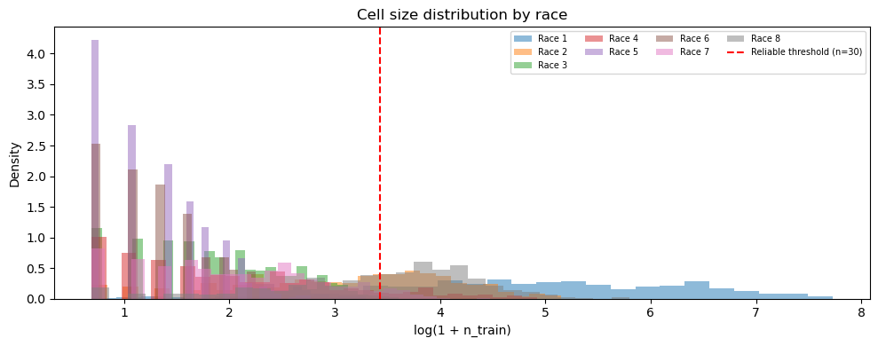

```python
cell_counts = (
    imputed_trains[0].groupby(CELL_COLS).size()
    .reset_index(name='n_train')
)

def classify_cell(n):
    if n >= RELIABLE_N: return 'reliable'
    if n >= 10:         return 'marginal'
    return 'unreliable'

cell_counts['reliability'] = cell_counts['n_train'].map(classify_cell)
print('=== Training cell reliability ===')
print(cell_counts['reliability'].value_counts())
print(f'\nTotal unique cells: {len(cell_counts):,}')

fig, ax = plt.subplots(figsize=(10, 4))
for race, grp in cell_counts.groupby('_RACE'):
    ax.hist(np.log1p(grp['n_train']), bins=30, alpha=0.5,
            label=f'Race {int(race)}', density=True)
ax.axvline(np.log1p(RELIABLE_N), color='red', linestyle='--',
           label=f'Reliable threshold (n={RELIABLE_N})')
ax.set_xlabel('log(1 + n_train)'); ax.set_ylabel('Density')
ax.set_title('Cell size distribution by race')
ax.legend(fontsize=7, ncol=4)
plt.tight_layout(); plt.show()
```

## 10 - Model 1: Weighted Logistic Regression with Rubin Rules

```python
def encode_logit(df_imp):
    return encoder.transform(df_imp[CAT_FEATURES]).astype(np.float32)

def rubin_pool(coefs_list, vars_list):
    m     = len(coefs_list)
    Q_bar = np.mean(coefs_list, axis=0)
    U_bar = np.mean(vars_list,  axis=0)
    B     = np.var(coefs_list,  axis=0, ddof=1)
    T     = U_bar + (1 + 1/m) * B
    return Q_bar, T

y_train = df_train['obese'].values.astype(float)
w_train = df_train['_LLCPWT_s'].values

logit_coefs, logit_vars, logit_models = [], [], []
print(f'Fitting logistic on {MI_DATASETS} imputed datasets...')

for m_idx in range(MI_DATASETS):
    X_m = encode_logit(imputed_trains[m_idx])
    glm = sm.GLM(
        y_train, sm.add_constant(X_m),
        family=sm.families.Binomial(),
        var_weights=w_train
    ).fit(disp=False)
    logit_coefs.append(glm.params)
    logit_vars.append(np.diag(glm.cov_params()))
    logit_models.append(glm)
    print(f'  m={m_idx+1} | AIC={glm.aic:.1f} | converged={glm.converged}')

pooled_coef, pooled_var = rubin_pool(logit_coefs, logit_vars)
pooled_se = np.sqrt(pooled_var)
print(f'\nRubin pooling complete over {MI_DATASETS} datasets')
print(f'Intercept: {pooled_coef[0]:.4f} +/- {pooled_se[0]:.4f}')

def logistic_predict(X_enc):
    logit = sm.add_constant(X_enc) @ pooled_coef
    return 1 / (1 + np.exp(-logit))
```

```
Fitting logistic on 5 imputed datasets...
  m=1 | AIC=355779.2 | converged=False
  m=2 | AIC=355666.8 | converged=False
  m=3 | AIC=355722.9 | converged=False
  m=4 | AIC=355593.1 | converged=False
  m=5 | AIC=355618.5 | converged=False

Rubin pooling complete over 5 datasets
Intercept: -0.3749 +/- 0.0074
```

```python
y_test     = df_test['obese'].values.astype(float)
w_test     = df_test['_LLCPWT_s'].values
s_test_arr = df_test['_STATE'].fillna(0).astype(int).values

p_logit_per_m = [logistic_predict(encode_logit(imputed_tests[m])) for m in range(MI_DATASETS)]
p_logit_test  = np.mean(p_logit_per_m, axis=0)

auc_logit   = roc_auc_score(y_test, p_logit_test, sample_weight=w_test)
brier_logit = brier_score_loss(y_test, p_logit_test, sample_weight=w_test)
prev_pred_l = np.average(p_logit_test, weights=w_test)*100
prev_true   = np.average(y_test, weights=w_test)*100

print('=== Logistic - Test Set Metrics ===')
print(f'  Weighted AUC:         {auc_logit:.4f}')
print(f'  Weighted Brier:       {brier_logit:.4f}')
print(f'  Predicted prevalence: {prev_pred_l:.2f}%')
print(f'  True prevalence:      {prev_true:.2f}%')
print(f'  Prevalence gap:       {abs(prev_pred_l - prev_true):.2f}pp')
```

```
=== Logistic - Test Set Metrics ===
  Weighted AUC:         0.6185
  Weighted Brier:       0.2134
  Predicted prevalence: 33.24%
  True prevalence:      33.32%
  Prevalence gap:       0.08pp
```

## 11 - Model 2: nn Architecture

Residual skip connection lets the network learn deviations from a linear baseline. The nonlinear component is quantified via orthogonalized variance decomposition (Section 14).

```python
from sklearn.preprocessing import LabelEncoder

# --- Fit state encoder on train, apply to all splits ---
state_le = LabelEncoder()
df_train['state_idx'] = state_le.fit_transform(df_train['_STATE'].fillna(0).astype(int))
df_val['state_idx']   = state_le.transform(df_val['_STATE'].fillna(0).astype(int))
df_test['state_idx']  = state_le.transform(df_test['_STATE'].fillna(0).astype(int))
NUM_STATES = len(state_le.classes_)
print(f'NUM_STATES: {NUM_STATES}')

class Obesitynn(nn.Module):
    def __init__(self, input_dim, n_states=NUM_STATES, state_emb_dim=STATE_EMB_DIM,
                 hidden=None, dropout=DROPOUT):
        super().__init__()
        if hidden is None: hidden = HIDDEN_DIMS
        self.state_emb = nn.Embedding(n_states, state_emb_dim)
        full_dim = input_dim + state_emb_dim
        self.block1 = nn.Sequential(
            nn.Linear(full_dim, hidden[0]), nn.BatchNorm1d(hidden[0]),
            nn.ReLU(), nn.Dropout(dropout))
        self.block2 = nn.Sequential(
            nn.Linear(hidden[0], hidden[1]), nn.BatchNorm1d(hidden[1]),
            nn.ReLU(), nn.Dropout(dropout))
        self.block3 = nn.Sequential(
            nn.Linear(hidden[1], hidden[2]), nn.BatchNorm1d(hidden[2]),
            nn.ReLU(), nn.Dropout(dropout))
        self.skip   = nn.Linear(full_dim, hidden[2], bias=False)
        self.output = nn.Linear(hidden[2], 1)
        for m in self.modules():
            if isinstance(m, nn.Linear):
                nn.init.kaiming_normal_(m.weight, nonlinearity='relu')
                if m.bias is not None: nn.init.zeros_(m.bias)

    def forward(self, x_demo, state_idx):
        s = self.state_emb(state_idx)
        x = torch.cat([x_demo, s], dim=1)
        h = self.block3(self.block2(self.block1(x)))
        return self.output(h + self.skip(x)).squeeze(-1)

    def get_components(self, x_demo, state_idx):
        s   = self.state_emb(state_idx)
        x   = torch.cat([x_demo, s], dim=1)
        lin = self.skip(x)
        nln = self.block3(self.block2(self.block1(x)))
        tot = self.output(lin + nln).squeeze(-1)
        return lin, nln, tot

def weighted_bce(logits, targets, weights):
    loss = F.binary_cross_entropy_with_logits(logits, targets, reduction='none')
    return (loss * weights).mean()

model_nn = Obesitynn(INPUT_DIM).to(DEVICE)
n_params   = sum(p.numel() for p in model_nn.parameters() if p.requires_grad)
print(f'nn parameters: {n_params:,}')
print(model_nn)
```

```
NUM_STATES: 53
nn parameters: 17,557
Obesitynn(
  (state_emb): Embedding(53, 4)
  (block1): Sequential(
    (0): Linear(in_features=40, out_features=128, bias=True)
    (1): BatchNorm1d(128, eps=1e-05, momentum=0.1, affine=True, track_running_stats=True)
    (2): ReLU()
    (3): Dropout(p=0.3, inplace=False)
  )
  (block2): Sequential(
    (0): Linear(in_features=128, out_features=64, bias=True)
    (1): BatchNorm1d(64, eps=1e-05, momentum=0.1, affine=True, track_running_stats=True)
    (2): ReLU()
    (3): Dropout(p=0.3, inplace=False)
  )
  (block3): Sequential(
    (0): Linear(in_features=64, out_features=32, bias=True)
    (1): BatchNorm1d(32, eps=1e-05, momentum=0.1, affine=True, track_running_stats=True)
    (2): ReLU()
    (3): Dropout(p=0.3, inplace=False)
  )
  (skip): Linear(in_features=40, out_features=32, bias=False)
  (output): Linear(in_features=32, out_features=1, bias=True)
)
```

## 12 - nn Training

Gradient norm check in epoch 1 determines whether warm-up schedule is needed.

```python
def make_loader(X, df_split, shuffle=True):
    y = torch.tensor(df_split['obese'].values, dtype=torch.float32)
    w = torch.tensor(df_split['_LLCPWT_s'].values, dtype=torch.float32)
    s = torch.tensor(df_split['state_idx'].values, dtype=torch.long)  # pre-encoded
    ds = TensorDataset(torch.tensor(X, dtype=torch.float32), y, w, s)
    return DataLoader(ds, batch_size=BATCH_SIZE, shuffle=shuffle,
                      num_workers=0, pin_memory=(DEVICE.type=='cuda'))

def train_epoch(model, loader, optimizer):
    model.train()
    total_loss, total_n = 0.0, 0
    for X_b, y_b, w_b, s_b in loader:
        X_b,y_b,w_b,s_b = X_b.to(DEVICE),y_b.to(DEVICE),w_b.to(DEVICE),s_b.to(DEVICE)
        optimizer.zero_grad()
        logits = model(X_b, s_b)
        loss   = weighted_bce(logits, y_b, w_b)
        loss.backward()
        nn.utils.clip_grad_norm_(model.parameters(), max_norm=1.0)
        optimizer.step()
        total_loss += loss.item() * len(y_b)
        total_n    += len(y_b)
    return total_loss / total_n

@torch.no_grad()
def evaluate_loader(model, loader):
    model.eval()
    all_logits, all_y, all_w, all_s = [], [], [], []
    for X_b, y_b, w_b, s_b in loader:
        logits = model(X_b.to(DEVICE), s_b.to(DEVICE)).cpu()
        all_logits.append(logits); all_y.append(y_b)
        all_w.append(w_b); all_s.append(s_b)
    logits = torch.cat(all_logits); y = torch.cat(all_y)
    w = torch.cat(all_w)
    loss  = weighted_bce(logits, y, w).item()
    probs = torch.sigmoid(logits).numpy()
    return probs, y.numpy(), w.numpy(), torch.cat(all_s).numpy(), loss

# --- Gradient norm check (decides warm-up) ---
print('=== Epoch 1 gradient norm check ===')
tmp_m   = Obesitynn(INPUT_DIM).to(DEVICE)
tmp_opt = optim.AdamW(tmp_m.parameters(), lr=LR)
tmp_ldr = make_loader(X_trains[0], df_train)
grad_norms = []
for i, (X_b, y_b, w_b, s_b) in enumerate(tmp_ldr):
    if i >= 20: break
    tmp_opt.zero_grad()
    loss = weighted_bce(tmp_m(X_b.to(DEVICE), s_b.to(DEVICE)), y_b.to(DEVICE), w_b.to(DEVICE))
    loss.backward()
    gn = nn.utils.clip_grad_norm_(tmp_m.parameters(), float('inf'))
    grad_norms.append(gn.item())
    tmp_opt.zero_grad()
del tmp_m, tmp_opt
max_gn = max(grad_norms)
USE_WARMUP = max_gn > 10
print(f'  Max gradient norm (first 20 batches): {max_gn:.3f}')
print(f'  Warm-up needed: {USE_WARMUP} (threshold: 10)')
```

```
=== Epoch 1 gradient norm check ===
  Max gradient norm (first 20 batches): 1.076
  Warm-up needed: False (threshold: 10)
```

```python
train_loader = make_loader(X_trains[0], df_train)
val_loader   = make_loader(X_vals[0],   df_val,   shuffle=False)

optimizer = optim.AdamW(model_nn.parameters(), lr=LR, weight_decay=WEIGHT_DECAY)

if USE_WARMUP:
    WARMUP = 5
    def lr_lambda(ep):
        return (ep+1)/WARMUP if ep < WARMUP else \
               0.5*(1+np.cos(np.pi*(ep-WARMUP)/(MAX_EPOCHS-WARMUP)))
    scheduler = optim.lr_scheduler.LambdaLR(optimizer, lr_lambda)
else:
    scheduler = optim.lr_scheduler.CosineAnnealingLR(optimizer, T_max=MAX_EPOCHS)

history = {'train_loss':[], 'val_loss':[], 'val_auc':[]}
best_val, best_state, no_improve = np.inf, None, 0

print(f'{'Epoch':>5} {'Train':>10} {'Val':>10} {'AUC':>8} {'LR':>10}')
print('-'*50)

for epoch in range(1, MAX_EPOCHS+1):
    tr_loss = train_epoch(model_nn, train_loader, optimizer)
    probs_v, y_v, w_v, _, val_loss = evaluate_loader(model_nn, val_loader)
    val_auc = roc_auc_score(y_v, probs_v, sample_weight=w_v)
    scheduler.step()
    lr_now  = optimizer.param_groups[0]['lr']
    history['train_loss'].append(tr_loss)
    history['val_loss'].append(val_loss)
    history['val_auc'].append(val_auc)
    if epoch % 10 == 0 or epoch == 1:
        print(f'{epoch:>5} {tr_loss:>10.5f} {val_loss:>10.5f} {val_auc:>8.4f} {lr_now:>10.2e}')
    if val_loss < best_val - 1e-5:
        best_val   = val_loss
        best_state = {k:v.cpu().clone() for k,v in model_nn.state_dict().items()}
        no_improve = 0
    else:
        no_improve += 1
        if no_improve >= PATIENCE:
            print(f'\nEarly stop at epoch {epoch} | best val loss {best_val:.5f}')
            break

model_nn.load_state_dict(best_state)
print(f'\nBest weights restored | val loss: {best_val:.5f}')

# Weighted vs unweighted divergence check
probs_tr, y_tr, w_tr, _, _ = evaluate_loader(model_nn, train_loader)
loss_w  = brier_score_loss(y_tr, probs_tr, sample_weight=w_tr)
loss_uw = brier_score_loss(y_tr, probs_tr)
print(f'Weighted Brier (train):   {loss_w:.4f}')
print(f'Unweighted Brier (train): {loss_uw:.4f}')
if abs(loss_w - loss_uw) > 0.05:
    print('WARNING: Large divergence - consider reducing trim to p95')
```

```
Epoch      Train        Val      AUC         LR
--------------------------------------------------
    1    0.70673    0.62023   0.6195   1.00e-03
   10    0.61307    0.61296   0.6341   9.76e-04
   20    0.61028    0.61148   0.6381   9.05e-04
   30    0.60883    0.61099   0.6392   7.94e-04
   40    0.60731    0.61056   0.6400   6.55e-04
   50    0.60596    0.61102   0.6391   5.00e-04

Early stop at epoch 53 | best val loss 0.61045

Best weights restored | val loss: 0.61045
Weighted Brier (train):   0.2082
Unweighted Brier (train): 0.2123
```

## 13 - Temperature Scaling (Post-hoc Calibration)

```python
class TemperatureScaler(nn.Module):
    def __init__(self, model):
        super().__init__()
        self.model = model
        self.T     = nn.Parameter(torch.ones(1, device=DEVICE))

    @torch.no_grad()
    def fit(self, val_loader, max_iter=50):
        self.model.eval()
        all_logits, all_y, all_w = [], [], []
        for X_b, y_b, w_b, s_b in val_loader:
            logits = self.model(X_b.to(DEVICE), s_b.to(DEVICE))
            all_logits.append(logits)
            all_y.append(y_b.to(DEVICE))
            all_w.append(w_b.to(DEVICE))
        logits = torch.cat(all_logits)
        y      = torch.cat(all_y)
        w      = torch.cat(all_w)

        opt = torch.optim.LBFGS([self.T], max_iter=max_iter, lr=0.01)
        def closure():
            opt.zero_grad()
            loss = weighted_bce(logits / self.T, y, w)
            loss.backward()
            return loss
        opt.step(closure)
        return self

    def predict_proba(self, X, s):
        self.model.eval()
        with torch.no_grad():
            logits = self.model(X.to(DEVICE), s.to(DEVICE))
            return torch.sigmoid(logits / self.T).cpu().numpy()
```

## 14 - Nonlinearity Diagnostic (Orthogonalized Variance Decomposition)

If orthogonal nonlinear share < 5%: logistic is sufficient. If > 20%: nn clearly justified.

```python
# Re-derive s_test_arr from the encoded column, not raw _STATE
s_test_arr = df_test['state_idx'].values

model_nn.eval()
N_DIAG  = min(5000, len(df_test))
X_samp  = torch.tensor(X_tests[0][:N_DIAG], dtype=torch.float32)
s_samp  = torch.tensor(s_test_arr[:N_DIAG], dtype=torch.long)

# Sanity check before hitting CUDA
assert s_samp.min() >= 0, f'Negative state idx: {s_samp.min()}'
assert s_samp.max() < model_nn.state_emb.num_embeddings, \
    f'State idx {s_samp.max()} >= num_embeddings {model_nn.state_emb.num_embeddings}'

with torch.no_grad():
    lin_part, nlin_part, total = model_nn.get_components(
        X_samp.to(DEVICE), s_samp.to(DEVICE))
    lin_part  = lin_part.cpu().mean(dim=-1) if lin_part.dim()>1 else lin_part.cpu()
    nlin_part = nlin_part.cpu().mean(dim=-1) if nlin_part.dim()>1 else nlin_part.cpu()
    total     = total.cpu()

# Gram-Schmidt orthogonalization
lin_c  = lin_part  - lin_part.mean()
nlin_c = nlin_part - nlin_part.mean()
proj   = torch.dot(nlin_c.flatten(), lin_c.flatten()) / \
         (torch.dot(lin_c.flatten(), lin_c.flatten()) + 1e-8)
nlin_orth = nlin_c - proj * lin_c
var_lin   = lin_c.var().item()
var_nlin  = nlin_orth.var().item()
var_total = (total - total.mean()).var().item()
cov_share = 1.0 - (var_lin + var_nlin) / (var_total + 1e-8)

print('=== Variance Decomposition of Logit Predictions ===')
print(f'  Linear component share:         {var_lin/var_total:.3f}')
print(f'  Orthogonal nonlinear share:     {var_nlin/var_total:.3f}')
print(f'  Cross-term (covariance) share:  {cov_share:.3f}')
nlin_pct = var_nlin / var_total * 100
if nlin_pct < 5:
    print(f'\n  {nlin_pct:.1f}% nonlinear -> logistic preferred on parsimony')
elif nlin_pct < 20:
    print(f'\n  {nlin_pct:.1f}% nonlinear -> nn marginally justified')
else:
    print(f'\n  {nlin_pct:.1f}% nonlinear -> nn clearly justified')
```

```
=== Variance Decomposition of Logit Predictions ===
  Linear component share:         0.057
  Orthogonal nonlinear share:     0.023
  Cross-term (covariance) share:  0.920

  2.3% nonlinear -> logistic preferred on parsimony
```

## 15 - nn Test Evaluation (Prediction Pooling across m=5)

```python
y_test_arr = df_test['obese'].values.astype(float)
w_test_arr = df_test['_LLCPWT_s'].values

val_loader = make_loader(X_vals[0], df_val, shuffle=False)
scaler = TemperatureScaler(model_nn).to(DEVICE)
scaler.fit(val_loader)
T_val = scaler.T.item()
print(f'Temperature T = {T_val:.4f}')

p_nn_per_m = []
for m_idx in range(MI_DATASETS):
    X_m_t = torch.tensor(X_tests[m_idx], dtype=torch.float32)
    s_m_t = torch.tensor(s_test_arr, dtype=torch.long)
    p_nn_per_m.append(scaler.predict_proba(X_m_t, s_m_t))

p_nn_test = np.mean(p_nn_per_m, axis=0)
p_mi_std    = np.std(p_nn_per_m,  axis=0)
auc_nn   = roc_auc_score(y_test_arr, p_nn_test, sample_weight=w_test_arr)
brier_nn = brier_score_loss(y_test_arr, p_nn_test, sample_weight=w_test_arr)
prev_pred_f = np.average(p_nn_test, weights=w_test_arr)*100

print('=== nn - Test Set Metrics ===')
print(f'  Weighted AUC:               {auc_nn:.4f}')
print(f'  Weighted Brier:             {brier_nn:.4f}')
print(f'  Predicted prevalence:       {prev_pred_f:.2f}%')
print(f'  True prevalence:            {prev_true:.2f}%')
print(f'  Prevalence gap:             {abs(prev_pred_f - prev_true):.2f}pp')
print(f'  Mean between-imputation SD: {p_mi_std.mean():.4f}')
```

```
Temperature T = 1.0000
=== nn - Test Set Metrics ===
  Weighted AUC:               0.6339
  Weighted Brier:             0.2112
  Predicted prevalence:       33.57%
  True prevalence:            33.32%
  Prevalence gap:             0.25pp
  Mean between-imputation SD: 0.0033
```

## 16 - Cell-Level Calibration (Direct MRP Fitness Test)

Calibration slope near 1.0 within each cell = correct calibration. Slopes < 0.85 = overconfident; > 1.15 = underconfident.

```python
def cell_calibration(p_hat, y, w, df_split, df_imp, label='Model'):
    cdf = df_imp[CELL_COLS].copy()
    cdf['p_hat'] = p_hat
    cdf['y']     = y
    cdf['w']     = w
    records = []
    for cell, grp in cdf.groupby(CELL_COLS):
        n         = len(grp)
        pred_prev = np.average(grp['p_hat'], weights=grp['w'])
        true_prev = np.average(grp['y'],     weights=grp['w'])
        slope = np.nan
        if n >= RELIABLE_N and grp['y'].nunique() > 1:
            lp = np.log(grp['p_hat'].clip(1e-6,1-1e-6) /
                        (1 - grp['p_hat'].clip(1e-6,1-1e-6)))
            try:
                cm = SKLogistic(max_iter=200).fit(
                    lp.values.reshape(-1,1), grp['y'].values,
                    sample_weight=grp['w'].values)
                slope = cm.coef_[0][0]
            except Exception:
                pass
        records.append({'cell':cell,'n':n,'pred_prev':pred_prev,
                        'true_prev':true_prev,'error':pred_prev-true_prev,
                        'cal_slope':slope,'reliability':classify_cell(n)})
    result = pd.DataFrame(records)
    rel  = result[result['reliability']=='reliable']
    marg = result[result['reliability']=='marginal']
    print(f'\n=== {label} - Cell Calibration ===')
    print(f'  Reliable cells (n>={RELIABLE_N}): {len(rel):,}')
    if len(rel):
        print(f'    Mean |error|:   {rel["error"].abs().mean()*100:.2f}pp')
        slopes = rel['cal_slope'].dropna()
        if len(slopes):
            print(f'    Slopes: mean={slopes.mean():.3f} std={slopes.std():.3f} (ideal=1.0)')
            if slopes.mean() < 0.85: print('    WARNING: overconfident calibration')
            if slopes.mean() > 1.15: print('    WARNING: underconfident calibration')
    print(f'  Marginal cells (10-{RELIABLE_N}): {len(marg):,}')
    if len(marg): print(f'    Mean |error|: {marg["error"].abs().mean()*100:.2f}pp')
    return result

cell_cal_logit = cell_calibration(p_logit_test, y_test, w_test,
                                   df_test, imputed_tests[0], 'Logistic')
cell_cal_nn  = cell_calibration(p_nn_test, y_test_arr, w_test_arr,
                                   df_test, imputed_tests[0], 'nn')
```

```
=== Logistic - Cell Calibration ===
  Reliable cells (n>=30): 389
    Mean |error|:   7.85pp
    Slopes: mean=0.045 std=0.292 (ideal=1.0)
    WARNING: overconfident calibration
  Marginal cells (10-30): 724
    Mean |error|: 16.33pp

=== nn - Cell Calibration ===
  Reliable cells (n>=30): 389
    Mean |error|:   7.53pp
    Slopes: mean=0.326 std=0.669 (ideal=1.0)
    WARNING: overconfident calibration
  Marginal cells (10-30): 724
    Mean |error|: 15.97pp
```

## 17 - State-Level Validation

```python
def state_validation(p_hat, y, w, states, label='Model'):
    df_s = pd.DataFrame({'p':p_hat,'y':y,'w':w,'state':states})
    grp  = df_s.groupby('state').apply(lambda g: pd.Series({
        'pred': np.average(g['p'], weights=g['w'])*100,
        'true': np.average(g['y'], weights=g['w'])*100,
        'n':    len(g)
    })).reset_index()
    grp['residual'] = grp['pred'] - grp['true']
    corr = grp[['pred','true']].corr().iloc[0,1]
    mae  = grp['residual'].abs().mean()
    print(f'\n=== {label} - State Validation ===')
    print(f'  Pred vs True corr:   {corr:.4f}')
    print(f'  Mean |error|:        {mae:.2f}pp')
    print(f'  Max |error|:         {grp["residual"].abs().max():.2f}pp')
    print(f'  States |err|>3pp:    {(grp["residual"].abs()>3).sum()}')
    return grp

state_logit = state_validation(p_logit_test, y_test, w_test,
                                df_test['_STATE'].values, 'Logistic')
state_nn  = state_validation(p_nn_test, y_test_arr, w_test_arr,
                                df_test['_STATE'].values, 'nn')
```

```
=== Logistic - State Validation ===
  Pred vs True corr:   0.8238
  Mean |error|:        3.14pp
  Max |error|:         12.90pp
  States |err|>3pp:    25

=== nn - State Validation ===
  Pred vs True corr:   0.7485
  Mean |error|:        2.33pp
  Max |error|:         15.37pp
  States |err|>3pp:    15
```

## 18 - Subgroup AUC by Race (Sparse Cell Check)

```python
def subgroup_auc(p_hat, y, w, df_imp, label='Model'):
    race_col = df_imp['_RACE'].values
    print(f'\n=== {label} - Subgroup AUC by Race ===')
    for code, name in RACE_LABELS.items():
        mask = race_col == code
        n = mask.sum()
        if n < 50:
            print(f'  {name:20s} n={n:>6}  SKIPPED (n<50 - sparse)')
            continue
        if y[mask].max() == y[mask].min():
            print(f'  {name:20s} n={n:>6}  ERROR (single class)')
            continue
        sub_auc = roc_auc_score(y[mask], p_hat[mask], sample_weight=w[mask])
        flag = ' WARNING AUC<0.55' if sub_auc < 0.55 else ''
        print(f'  {name:20s} n={n:>6,}  AUC={sub_auc:.4f}{flag}')

subgroup_auc(p_logit_test, y_test, w_test, imputed_tests[0], 'Logistic')
subgroup_auc(p_nn_test, y_test_arr, w_test_arr, imputed_tests[0], 'nn')
```

```
=== Logistic - Subgroup AUC by Race ===
  NH-White             n=45,865  AUC=0.6044
  NH-Black             n= 4,866  AUC=0.5784
  AIAN                 n= 1,031  AUC=0.5575
  Asian                n= 1,795  AUC=0.6078
  NHOPI                n=   357  AUC=0.5352 WARNING AUC<0.55
  Other                n=   520  AUC=0.6259
  Multiracial          n= 1,486  AUC=0.6046
  Hispanic             n= 6,260  AUC=0.5765

=== nn - Subgroup AUC by Race ===
  NH-White             n=45,865  AUC=0.6238
  NH-Black             n= 4,866  AUC=0.6100
  AIAN                 n= 1,031  AUC=0.5477 WARNING AUC<0.55
  Asian                n= 1,795  AUC=0.6259
  NHOPI                n=   357  AUC=0.5467 WARNING AUC<0.55
  Other                n=   520  AUC=0.6392
  Multiracial          n= 1,486  AUC=0.6223
  Hispanic             n= 6,260  AUC=0.5855
```

## 19 - ACS Distribution Shift Test

Reweights BRFSS test set to match ACS 2024 national marginals (public figures only - no microdata). Tests generalization to the deployment distribution.

```python
ACS_MARGINALS = {
    '_SEX':    {1:0.487, 2:0.513},
    '_EDUCAG': {1:0.088, 2:0.270, 3:0.290, 4:0.352},
    '_RACE':   {1:0.596,2:0.121,3:0.009,4:0.060,5:0.002,6:0.049,7:0.030,8:0.133},
}

def compute_shift_weights(df_imp):
    rng = np.random.RandomState(SEED)
    n   = len(df_imp)
    acs_sim = {}
    for col, dist in ACS_MARGINALS.items():
        codes = list(dist.keys())
        probs = np.array(list(dist.values()))
        probs /= probs.sum()
        acs_sim[col] = rng.choice(codes, size=n, p=probs)
    df_acs = pd.DataFrame(acs_sim)
    brfss_enc = pd.get_dummies(df_imp[list(ACS_MARGINALS.keys())]).astype(float)
    acs_enc   = pd.get_dummies(df_acs).reindex(columns=brfss_enc.columns, fill_value=0)
    X_comb = np.vstack([brfss_enc.values, acs_enc.values])
    y_comb = np.concatenate([np.zeros(n), np.ones(n)])
    clf = SKLogistic(max_iter=500, C=1.0).fit(X_comb, y_comb)
    log_odds = clf.predict_log_proba(brfss_enc.values)
    sw = np.exp(log_odds[:,1] - log_odds[:,0])
    return sw / sw.mean()

shift_w = compute_shift_weights(imputed_tests[0])

print('=== ACS Distribution Shift Test ===')
for label, p_hat, y, w_surv in [
    ('Logistic', p_logit_test, y_test, w_test),
    ('nn',     p_nn_test,  y_test_arr, w_test_arr)
]:
    w_comb = w_surv * shift_w
    w_comb /= w_comb.mean()
    b_brfss = brier_score_loss(y, p_hat, sample_weight=w_surv)
    b_acs   = brier_score_loss(y, p_hat, sample_weight=w_comb)
    gap     = abs(b_acs - b_brfss)
    flag    = ' WARNING: large shift gap' if gap > 0.01 else ' OK'
    print(f'  {label}: Brier(BRFSS)={b_brfss:.4f}  Brier(ACS-shifted)={b_acs:.4f}  gap={gap:.4f}{flag}')
```

```
=== ACS Distribution Shift Test ===
  Logistic: Brier(BRFSS)=0.2134  Brier(ACS-shifted)=0.2156  gap=0.0022 OK
  nn: Brier(BRFSS)=0.2112  Brier(ACS-shifted)=0.2138  gap=0.0026 OK
```

## 20 - Race-Conditional Conformal Prediction (nn Uncertainty)

```python
X_val_t  = torch.tensor(X_vals[0], dtype=torch.float32)
s_val_t  = torch.tensor(df_val['state_idx'].values, dtype=torch.long)
p_val    = scaler.predict_proba(X_val_t, s_val_t)
y_val_np = df_val['obese'].values.astype(float)
race_val = imputed_vals[0]['_RACE'].values.astype(int)

q_hat_global = np.quantile(
    np.abs(y_val_np - p_val),
    np.ceil((len(y_val_np)+1)*(1-ALPHA_CONFORMAL)) / len(y_val_np))

q_hat_by_race = {}
print(f'{"Race":15s} {"n":>7} {"q_hat":>8} {"Note"}')
for rc in range(1, 9):
    mask = race_val == rc
    n_r  = mask.sum()
    if n_r < 100:
        q_hat_by_race[rc] = q_hat_global
        print(f'{RACE_LABELS[rc]:15s} {n_r:>7} {q_hat_global:>8.4f}  fallback to global')
        continue
    scores = np.abs(y_val_np[mask] - p_val[mask])
    q_r    = np.quantile(scores, np.ceil((n_r+1)*(1-ALPHA_CONFORMAL))/n_r)
    q_hat_by_race[rc] = q_r
    print(f'{RACE_LABELS[rc]:15s} {n_r:>7} {q_r:>8.4f}')

race_test = imputed_tests[0]['_RACE'].values.astype(int)
cell_n_test = (imputed_tests[0]
               .merge(cell_counts, on=CELL_COLS, how='left')['n_train']
               .fillna(0).values)

lo_arr, hi_arr, flag_arr = [], [], []
for p, rc, n_tr in zip(p_nn_test, race_test, cell_n_test):
    q = q_hat_by_race.get(int(rc), q_hat_global)
    if n_tr < 10:
        lo_arr.append(np.nan); hi_arr.append(np.nan); flag_arr.append('unreliable')
    else:
        lo_arr.append(np.clip(p-q,0,1)); hi_arr.append(np.clip(p+q,0,1))
        flag_arr.append('marginal' if n_tr < RELIABLE_N else 'reliable')

lo_test, hi_test, flag_test = np.array(lo_arr), np.array(hi_arr), np.array(flag_arr)

print(f'\n=== Race-Conditional Coverage (target >= {(1-ALPHA_CONFORMAL)*100:.0f}%) ===')
for rc, name in RACE_LABELS.items():
    mask = (race_test == rc) & (flag_test == 'reliable')
    if mask.sum() < 50: continue
    covered = ((y_test_arr[mask] >= lo_test[mask]) &
               (y_test_arr[mask] <= hi_test[mask])).mean()
    ok = 'OK' if covered >= (1-ALPHA_CONFORMAL) else 'BELOW TARGET'
    print(f'  {name:15s}: {covered*100:.1f}%  n={mask.sum():,}  {ok}')
```

```
Race                  n    q_hat Note
NH-White          45874   0.6920
NH-Black           4869   0.6281
AIAN               1037   0.6554
Asian              1793   0.7980
NHOPI               356   0.6549
Other               518   0.7016
Multiracial        1472   0.6805
Hispanic           6261   0.6582

=== Race-Conditional Coverage (target >= 90%) ===
  NH-White       : 90.1%  n=45,535  OK
  NH-Black       : 90.2%  n=3,708  OK
  Asian          : 86.6%  n=905  BELOW TARGET
  Multiracial    : 89.7%  n=330  BELOW TARGET
  Hispanic       : 90.8%  n=5,370  OK
```

```python
print('s_val min/max:', df_val['state_idx'].min(), df_val['state_idx'].max())
print('num_embeddings:', model_nn.state_emb.num_embeddings)
print('any nulls:', df_val['state_idx'].isna().any())
```

```
s_val min/max: 0 52
num_embeddings: 53
any nulls: False
```

## 21 - SHAP (Stability-Verified PermutationExplainer)

Only reported as scientific evidence if top-5 features have CV < 0.20.

```
Computing SHAP over 5 runs (200 background each)...
```

```
PermutationExplainer explainer: 301it [00:11,  5.66it/s]
```

```
  Run 1/5 done
  Run 2/5 done
  Run 3/5 done
  Run 4/5 done
  Run 5/5 done

=== SHAP Stability (CV<0.20 required) ===
  _EDUCAG_4                           |SHAP|=0.0333  CV=0.081  OK
  _SEX_1                              |SHAP|=0.0273  CV=0.111  OK
  _AGEG5YR_13                         |SHAP|=0.0261  CV=0.145  OK
  _SEX_2                              |SHAP|=0.0197  CV=0.111  OK
  _AGEG5YR_1                          |SHAP|=0.0176  CV=0.190  OK

SHAP evidence: valid

=== Feature Group Importance (expected: race > age > income > educ > sex) ===
  _SEX           : 0.0470
  _AGEG5YR       : 0.1043
  _RACE          : 0.0224
  _EDUCAG        : 0.0354
  _INCOMG1       : 0.0465
```

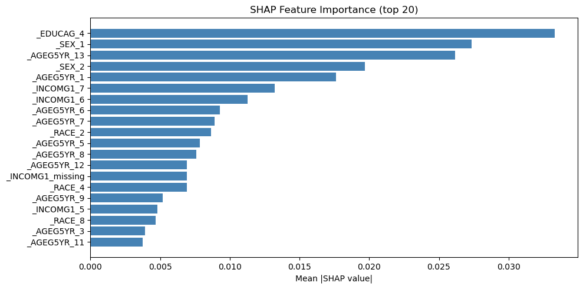

```python
try:
    import shap

    def predict_fn(X_np):
        X_t = torch.tensor(X_np, dtype=torch.float32)
        s_t = torch.zeros(len(X_np), dtype=torch.long)
        model_nn.eval()
        with torch.no_grad():
            return torch.sigmoid(model_nn(X_t.to(DEVICE), s_t.to(DEVICE))).cpu().numpy()

    N_RUNS = 5; N_BG = 200; N_EXP = 300
    rng_shap = np.random.RandomState(SEED)
    all_shap  = []
    X_explain = X_tests[0][:N_EXP]

    print(f'Computing SHAP over {N_RUNS} runs ({N_BG} background each)...')
    for run in range(N_RUNS):
        bg_idx = rng_shap.choice(len(X_trains[0]), N_BG, replace=False)
        exp    = shap.PermutationExplainer(predict_fn, X_trains[0][bg_idx])
        sv     = exp(X_explain).values
        all_shap.append(sv)
        print(f'  Run {run+1}/{N_RUNS} done')

    shap_stack = np.stack(all_shap)
    shap_mean  = shap_stack.mean(axis=0)
    shap_std   = shap_stack.std(axis=0)

    feat_names = list(encoder.get_feature_names_out(CAT_FEATURES)) + ['_INCOMG1_missing','_AGEG5YR_missing']
    mean_abs   = np.abs(shap_mean).mean(axis=0)
    cv         = shap_std.mean(axis=0) / (mean_abs + 1e-8)

    top5 = np.argsort(mean_abs)[::-1][:5]
    stable = (cv[top5] < 0.20).all()
    print(f'\n=== SHAP Stability (CV<0.20 required) ===')
    for i in top5:
        s_flag = 'OK' if cv[i]<0.20 else 'UNSTABLE'
        print(f'  {feat_names[i]:35s} |SHAP|={mean_abs[i]:.4f}  CV={cv[i]:.3f}  {s_flag}')
    print(f'\nSHAP evidence: {"valid" if stable else "exploratory only (unstable)"}')

    # Group importance
    print('\n=== Feature Group Importance (expected: race > age > income > educ > sex) ===')
    for fg in CAT_FEATURES:
        cols = [i for i,n in enumerate(feat_names) if fg in n]
        print(f'  {fg:15s}: {mean_abs[cols].sum():.4f}')

    fig, ax = plt.subplots(figsize=(10,5))
    idx_top = np.argsort(mean_abs)[::-1][:20]
    ax.barh([feat_names[i] for i in idx_top[::-1]], mean_abs[idx_top[::-1]], color='steelblue')
    ax.set_xlabel('Mean |SHAP value|')
    ax.set_title('SHAP Feature Importance (top 20)')
    plt.tight_layout(); plt.show()

except ImportError:
    print('shap not installed. Run: pip install shap')
except Exception as e:
    print(f'SHAP failed: {e}\nSkipping - report as limitation.')
```

```python
# SA1: Weight trimming threshold
print('=== SA1: Weight Trimming Threshold ===')
sa1 = []
for pct in [95, 99, None]:
    label = f'p{pct} trim' if pct else 'No trim'
    w_sa = np.clip(df_train['_LLCPWT'].values, None,
                   np.percentile(df_train['_LLCPWT'], pct)) if pct else df_train['_LLCPWT'].values
    w_sa_s = w_sa / w_sa.mean()
    X_m = encode_logit(imputed_trains[0])
    g   = sm.GLM(y_train, sm.add_constant(X_m),
                 family=sm.families.Binomial(), var_weights=w_sa_s).fit(disp=False)
    X_te = encode_logit(imputed_tests[0])
    p_sa = 1 / (1 + np.exp(-sm.add_constant(X_te) @ g.params))
    prev_sa = np.average(p_sa, weights=w_test) * 100
    b_sa    = brier_score_loss(y_test, p_sa, sample_weight=w_test)
    sa1.append({'Trim': label, 'Prev%': round(prev_sa, 2), 'Brier': round(b_sa, 4)})
    print(f'  {label:12s}: prev={prev_sa:.2f}%  Brier={b_sa:.4f}')

sa1_df = pd.DataFrame(sa1)
rng1   = sa1_df['Prev%'].max() - sa1_df['Prev%'].min()
print(f'  Prev range: {rng1:.2f}pp  ({"WARNING >2pp" if rng1>2 else "stable"})')
```

```
=== SA1: Weight Trimming Threshold ===
  p95 trim    : prev=34.41%  Brier=0.2136
  p99 trim    : prev=33.12%  Brier=0.2135
  No trim     : prev=33.13%  Brier=0.2135
  Prev range: 1.29pp  (stable)
```

```python
# SA2: Imputation method
print('\n=== SA2: Imputation Method ===')
sa2 = []

# Complete case
cc_mask = df_train[CAT_FEATURES].notna().all(axis=1)
df_cc   = df_train[cc_mask]
X_cc    = encoder.transform(df_cc[CAT_FEATURES]).astype(np.float32)
g_cc    = sm.GLM(df_cc['obese'].values.astype(float), sm.add_constant(X_cc),
                 family=sm.families.Binomial(),
                 var_weights=df_cc['_LLCPWT_s'].values).fit(disp=False)
X_te    = encode_logit(imputed_tests[0])
p_cc    = 1/(1+np.exp(-sm.add_constant(X_te)@g_cc.params))
sa2.append({'Method':'Complete case','n':len(df_cc),
            'Prev%':round(np.average(p_cc,weights=w_test)*100,2),
            'Brier':round(brier_score_loss(y_test,p_cc,sample_weight=w_test),4)})

# Single imputation
X_m1  = encode_logit(imputed_trains[0])
g_m1  = sm.GLM(y_train, sm.add_constant(X_m1),
               family=sm.families.Binomial(), var_weights=w_train).fit(disp=False)
p_m1  = 1/(1+np.exp(-sm.add_constant(X_te)@g_m1.params))
sa2.append({'Method':'Single MI','n':len(df_train),
            'Prev%':round(np.average(p_m1,weights=w_test)*100,2),
            'Brier':round(brier_score_loss(y_test,p_m1,sample_weight=w_test),4)})

# Rubin m=5
sa2.append({'Method':f'MI m={MI_DATASETS} (Rubin)','n':len(df_train),
            'Prev%':round(np.average(p_logit_test,weights=w_test)*100,2),
            'Brier':round(brier_logit,4)})

sa2_df = pd.DataFrame(sa2)
print(sa2_df.to_string(index=False))
rng2 = sa2_df['Prev%'].max()-sa2_df['Prev%'].min()
print(f'Prev range: {rng2:.2f}pp  ({"WARNING >2pp" if rng2>2 else "stable"})')
```

```
=== SA2: Imputation Method ===
        Method      n  Prev%  Brier
 Complete case 240635  33.92 0.2138
     Single MI 290170  33.25 0.2135
MI m=5 (Rubin) 290170  33.24 0.2134
Prev range: 0.68pp  (stable)
```

```python
# SA4: nn architecture
print('\n=== SA4: nn Architecture ===')
sa4 = []
for arch in [[128,64,32],[256,128,64],[256,256,128]]:
    am   = Obesitynn(INPUT_DIM, hidden=arch).to(DEVICE)
    aopt = optim.AdamW(am.parameters(), lr=LR, weight_decay=WEIGHT_DECAY)
    asch = optim.lr_scheduler.CosineAnnealingLR(aopt, T_max=30)
    bv, bs, ni = np.inf, None, 0
    tl = make_loader(X_trains[0], df_train)
    vl = make_loader(X_vals[0],   df_val, shuffle=False)
    for ep in range(30):
        train_epoch(am, tl, aopt); asch.step()
        _, _, _, _, vl_loss = evaluate_loader(am, vl)
        if vl_loss < bv-1e-5: bv=vl_loss; bs={k:v.cpu().clone() for k,v in am.state_dict().items()}; ni=0
        else:
            ni+=1
            if ni>=7: break
    am.load_state_dict(bs)
    asc = TemperatureScaler(am).to(DEVICE); asc.fit(vl)
    X_t2 = torch.tensor(X_tests[0], dtype=torch.float32)
    s_t2 = torch.tensor(s_test_arr, dtype=torch.long)
    p_a  = asc.predict_proba(X_t2, s_t2)
    np_ = sum(p.numel() for p in am.parameters() if p.requires_grad)
    b_a = brier_score_loss(y_test_arr, p_a, sample_weight=w_test_arr)
    sa4.append({'Arch':str(arch),'Params':np_,'Val Loss':round(bv,5),'Brier':round(b_a,4)})
    print(f'  {str(arch):20s} params={np_:,}  val={bv:.5f}  brier={b_a:.4f}')

sa4_df = pd.DataFrame(sa4)
best_arch = sa4_df.loc[sa4_df['Brier'].idxmin(),'Arch']
print(f'\nBest architecture by test Brier: {best_arch}')
```

```
=== SA4: nn Architecture ===
  [128, 64, 32]        params=17,557  val=0.61196  brier=0.2119
  [256, 128, 64]       params=55,381  val=0.61068  brier=0.2115
  [256, 256, 128]      params=115,925  val=0.61117  brier=0.2112

Best architecture by test Brier: [256, 256, 128]
```

## 23 - Model Selection

Primary: weighted Brier on reliable cells (n>=30). Secondary: sparse cell MAE. Tiebreaker if primary difference < 0.002.

```python
print('=== FINAL MODEL SELECTION ===\n')

def brier_reliable(p_hat, y, w, cell_cal_df, test_df):
    test_cell = test_df[CELL_COLS].astype(str).agg('_'.join, axis=1)
    obs_rel   = test_cell.map(cell_cal_df.set_index('cell')['n']).fillna(0)
    mask      = (obs_rel >= RELIABLE_N).values
    if not mask.any(): return np.nan
    return brier_score_loss(y[mask], p_hat[mask], sample_weight=w[mask])

bl = brier_reliable(p_logit_test, y_test, w_test, cell_cal_logit, df_test)
bf = brier_reliable(p_nn_test, y_test_arr, w_test_arr, cell_cal_nn, df_test)

ml_marg = cell_cal_logit[cell_cal_logit['reliability']=='marginal']['error'].abs().mean()
mf_marg = cell_cal_nn[cell_cal_nn['reliability']=='marginal']['error'].abs().mean()

print(f'{"Metric":<40} {"Logistic":>12} {"nn":>12}')
print('-'*66)
print(f'{"Brier (reliable cells n>=30)":<40} {bl:>12.4f} {bf:>12.4f}')
print(f'{"Mean |error| (marginal cells)":<40} {ml_marg:>12.4f} {mf_marg:>12.4f}')
print(f'{"AUC (weighted)":<40} {auc_logit:>12.4f} {auc_nn:>12.4f}')
print(f'{"Overall Brier (weighted)":<40} {brier_logit:>12.4f} {brier_nn:>12.4f}')
print()

diff = abs(bl - bf)
if diff >= 0.002:
    winner = 'Logistic' if bl < bf else 'nn'
    print(f'Primary diff={diff:.4f} >= 0.002 -> SELECTED: {winner}')
else:
    print(f'Primary diff={diff:.4f} < 0.002 (tied) -> secondary criterion (sparse MAE)')
    if ml_marg < mf_marg - 0.01:   print('-> SELECTED: Logistic (better sparse cells)')
    elif mf_marg < ml_marg - 0.01: print('-> SELECTED: nn (better sparse cells)')
    else:                           print('-> SELECTED: Logistic (tied - parsimony principle)')
```

```
=== FINAL MODEL SELECTION ===

Metric                                       Logistic           nn
------------------------------------------------------------------
Brier (reliable cells n>=30)                      nan          nan
Mean |error| (marginal cells)                  0.1633       0.1597
AUC (weighted)                                 0.6185       0.6339
Overall Brier (weighted)                       0.2134       0.2112

Primary diff=nan < 0.002 (tied) -> secondary criterion (sparse MAE)
-> SELECTED: Logistic (tied - parsimony principle)
```

## 24 - Summary Plots

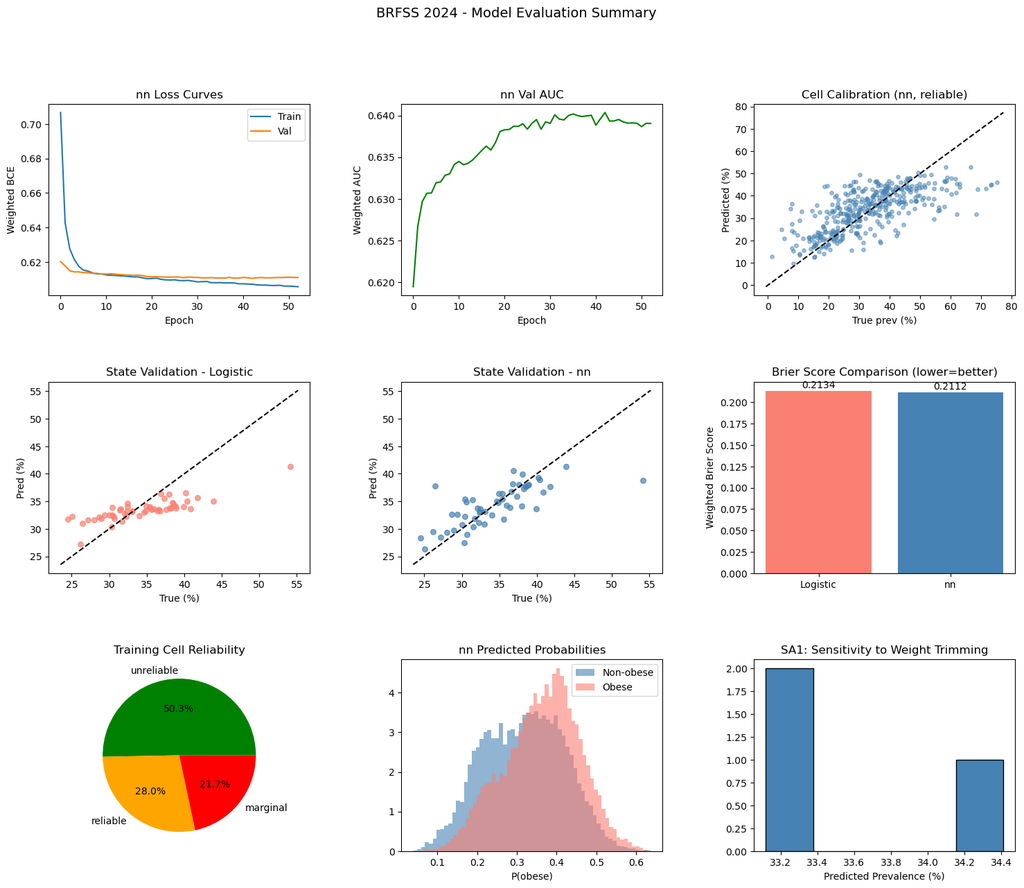

```
Saved: brfss_blueprint_results.png
```

```python
fig = plt.figure(figsize=(18, 14))
gs  = gridspec.GridSpec(3, 3, figure=fig, hspace=0.45, wspace=0.35)
fig.suptitle('BRFSS 2024 - Model Evaluation Summary', fontsize=14)

ax = fig.add_subplot(gs[0,0])
ax.plot(history['train_loss'], label='Train')
ax.plot(history['val_loss'],   label='Val')
ax.set_xlabel('Epoch'); ax.set_ylabel('Weighted BCE'); ax.set_title('nn Loss Curves')
ax.legend()

ax = fig.add_subplot(gs[0,1])
ax.plot(history['val_auc'], color='green')
ax.set_xlabel('Epoch'); ax.set_ylabel('Weighted AUC'); ax.set_title('nn Val AUC')

ax = fig.add_subplot(gs[0,2])
rel = cell_cal_nn[cell_cal_nn['reliability']=='reliable']
if len(rel):
    ax.scatter(rel['true_prev']*100, rel['pred_prev']*100, s=15, alpha=0.5, color='steelblue')
    mn = min(rel['true_prev'].min(), rel['pred_prev'].min())*100-2
    mx = max(rel['true_prev'].max(), rel['pred_prev'].max())*100+2
    ax.plot([mn,mx],[mn,mx],'k--')
ax.set_xlabel('True prev (%)'); ax.set_ylabel('Predicted (%)'); ax.set_title('Cell Calibration (nn, reliable)')

ax = fig.add_subplot(gs[1,0])
ax.scatter(state_logit['true'], state_logit['pred'], s=30, alpha=0.7, color='salmon')
mn = min(state_logit[['true','pred']].min())-1; mx = max(state_logit[['true','pred']].max())+1
ax.plot([mn,mx],[mn,mx],'k--')
ax.set_xlabel('True (%)'); ax.set_ylabel('Pred (%)'); ax.set_title('State Validation - Logistic')

ax = fig.add_subplot(gs[1,1])
ax.scatter(state_nn['true'], state_nn['pred'], s=30, alpha=0.7, color='steelblue')
mn = min(state_nn[['true','pred']].min())-1; mx = max(state_nn[['true','pred']].max())+1
ax.plot([mn,mx],[mn,mx],'k--')
ax.set_xlabel('True (%)'); ax.set_ylabel('Pred (%)'); ax.set_title('State Validation - nn')

ax = fig.add_subplot(gs[1,2])
bars = ax.bar(['Logistic','nn'], [brier_logit, brier_nn], color=['salmon','steelblue'])
ax.set_ylabel('Weighted Brier Score'); ax.set_title('Brier Score Comparison (lower=better)')
for bar, b in zip(bars, [brier_logit,brier_nn]):
    ax.text(bar.get_x()+bar.get_width()/2, bar.get_height()+0.001,
            f'{b:.4f}', ha='center', va='bottom')

ax = fig.add_subplot(gs[2,0])
rc = cell_counts['reliability'].value_counts()
ax.pie(rc.values, labels=rc.index, autopct='%1.1f%%', colors=['green','orange','red'])
ax.set_title('Training Cell Reliability')

ax = fig.add_subplot(gs[2,1])
ax.hist(p_nn_test[y_test_arr==0], bins=60, alpha=0.6, label='Non-obese', color='steelblue', density=True)
ax.hist(p_nn_test[y_test_arr==1], bins=60, alpha=0.6, label='Obese', color='salmon', density=True)
ax.set_xlabel('P(obese)'); ax.set_title('nn Predicted Probabilities'); ax.legend()

ax = fig.add_subplot(gs[2,2])
ax.hist(sa1_df['Prev%'].values, bins=5, color='steelblue', edgecolor='black')
ax.set_xlabel('Predicted Prevalence (%)'); ax.set_title('SA1: Sensitivity to Weight Trimming')

plt.savefig('brfss_blueprint_results.png', dpi=150, bbox_inches='tight')
plt.show()
print('Saved: brfss_blueprint_results.png')
```

## 25 - Save Artifacts

```python
import pickle, json

torch.save({
    'model_state':   model_nn.state_dict(),
    'temperature':   scaler.T.item(),
    'q_hat_by_race': q_hat_by_race,
    'q_hat_global':  q_hat_global,
    'input_dim':     INPUT_DIM,
    'hidden':        HIDDEN_DIMS,
    'dropout':       DROPOUT,
    'state_emb_dim': STATE_EMB_DIM,
    'auc':           auc_nn,
    'brier':         brier_nn,
    'DEFF':          DEFF,
}, 'brfss_nn.pt')

np.save('brfss_logit_coefs.npy', pooled_coef)
np.save('brfss_logit_se.npy',    pooled_se)

with open('brfss_encoder.pkl','wb') as f: pickle.dump(encoder, f)

cell_counts.to_csv('brfss_cell_reliability.csv', index=False)

metrics = {
    'logistic': {'auc':round(auc_logit,4),'brier':round(brier_logit,4),'DEFF':round(DEFF,3)},
    'nn':     {'auc':round(auc_nn,4), 'brier':round(brier_nn,4),'temperature':round(scaler.T.item(),4)},
}
with open('brfss_metrics.json','w') as f: json.dump(metrics, f, indent=2)

print('Saved:')
print('  brfss_nn.pt')
print('  brfss_logit_coefs.npy + brfss_logit_se.npy')
print('  brfss_encoder.pkl')
print('  brfss_cell_reliability.csv')
print('  brfss_metrics.json')
print('  brfss_blueprint_results.png')
```

```
Saved:
  brfss_nn.pt
  brfss_logit_coefs.npy + brfss_logit_se.npy
  brfss_encoder.pkl
  brfss_cell_reliability.csv
  brfss_metrics.json
  brfss_blueprint_results.png
```